# Machine Learning Implementation

Wenxuan Zhang

2023-03-26

## Linear Regression

### Local Regression

Local Regression is non parametric way to estimate the y. The basic idea of this model is : 1. Select the closet X ( in term of similarity) and then predict a model using these data. 2. The closer data get higher weights. Common used weight,
$$w^{i} =
exp(\frac{-(x^{i}-x)^2}{2\tau^{2}})$$

*Pros*: 1. Do not need to construct feature

*Cons*: 1. For large data set, it is memory costly

```r
library(ggplot2)
data(economics, package="ggplot2")  # load data
economics$index <- 1:nrow(economics)  # create index variable
economics <- economics[1:80, ]  # retail 80rows for better graphical understanding
loessMod10 <- loess(uempmed ~ index, data=economics, span=0.10) # 10% smoothing span
loessMod25 <- loess(uempmed ~ index, data=economics, span=0.25) # 25% smoothing span
loessMod50 <- loess(uempmed ~ index, data=economics, span=0.50) #
loessMod100 <- loess(uempmed ~ index, data=economics, span=1)
lm100 <- lm(uempmed ~ index, data = economics)
lm1003 <- lm(uempmed ~ index+I(index^2)+I(index^3),data = economics)
smoothed10 <- predict(loessMod10)
smoothed25 <- predict(loessMod25)
smoothed50 <- predict(loessMod50)
smoothed100 <- predict(loessMod100)
lm100_d <- predict(lm100)
lm1003_d <- predict(lm1003)

print(paste('MSE: model smoothed10:',round(mean((economics$uempmed-smoothed10)^2),2)))
```

```
## [1] "MSE: model smoothed10: 0.04"
```

```r
print(paste('MSE: model smoothed25:',round(mean((economics$uempmed-smoothed25)^2),2)))
```

```
## [1] "MSE: model smoothed25: 0.06"
```

```r
print(paste('MSE: model smoothed50:',round(mean((economics$uempmed-smoothed50)^2),2)))
```

```
## [1] "MSE: model smoothed50: 0.08"
```

```r
print(paste('MSE: model smoothed100:',round(mean((economics$uempmed-smoothed100)^2),2)))
```

```
## [1] "MSE: model smoothed100: 0.16"
```

```r
print(paste('MSE: model lm:',round(mean((economics$uempmed-lm100_d)^2),2)))
```

```
## [1] "MSE: model lm: 0.4"
```

```r
print(paste('MSE: model lm 1003:',round(mean((economics$uempmed-lm1003_d)^2),2)))
```

```
## [1] "MSE: model lm 1003: 0.15"
```

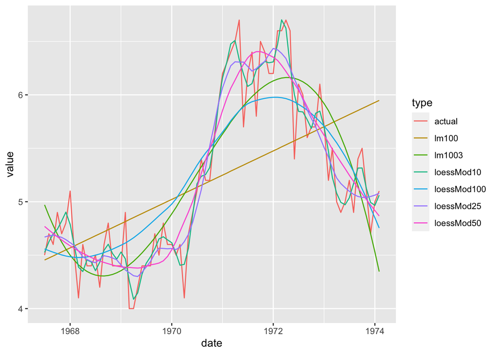

```r
# create data frame,
pred <- as.numeric(c(economics$uempmed,smoothed10,
              smoothed25,smoothed50,
              smoothed100,lm100_d,
              lm1003_d))
date <-rep(economics$date,7)
n_obs <- dim(economics)[1]
type = c(rep('actual',n_obs),
         rep('loessMod10',n_obs),
         rep('loessMod25',n_obs),
         rep('loessMod50',n_obs),
         rep('loessMod100',n_obs),
         rep('lm100',n_obs),
         rep('lm1003',n_obs))
eco_models <- data.frame(date = date, value = pred,type = type)

ggplot(data = eco_models, aes(date, value, group = type, color = type),main = 'Loess Smoothing and Prediction') + geom_line()
```

```r
if(FALSE){
loess(formula, data, weights, subset, na.action, model = FALSE,
      span = 0.75, enp.target, degree = 2,
      parametric = FALSE, drop.square = FALSE, normalize = TRUE,
      family = c("gaussian", "symmetric"),
      method = c("loess", "model.frame"),
      control = loess.control(...), ...)}
```

To learn more details about this model, please find (help(loess))

For $\alpha > 1$, all points are used, with the ‘maximum distance’ assumed to be $\alpha^{1/p}$ times the actual maximum distance for pp explanatory variables.

For the default family, fitting is by (weighted) least squares. For family=“symmetric” a few iterations of an M-estimation procedure with Tukey’s biweight are used. Be aware that as the initial value is the least-squares fit, this need not be a very resistant fit.

It can be important to tune the control list to achieve acceptable speed. See loess.control for details. ”

```r
# define function that returns the SSE,
calcSSE <- function(x=0.5){
  sse <- 99999
  loessMod <- try(loess(uempmed ~ index, data=economics, span=x), silent=T)
  res <- try(loessMod$residuals, silent=T)
  if(class(res)!="try-error"){
    if((sum(res, na.rm=T) > 0)){
      sse <- sum(res^2)
    }}

  return(sse)
}

optim(par=c(0.5), calcSSE, method="SANN")
```

```
## $par
## [1] 0.03913896
##
## $value
## [1] 7.888609e-31
##
## $counts
## function gradient
##    10000       NA
##
## $convergence
## [1] 0
##
## $message
## NULL
```

```r
final<-0.04598782
```

[Local Linear Regression](http://r-statistics.co/Loess-Regression-With-R.html)

```r
library(caret)
# find k fold optimization

#define k-fold cross validation method
ctrl <- trainControl(method = "cv", number = 5)
grid <- expand.grid(span = seq(0.5, 0.9, len = 5), degree = 1)

#perform cross-validation using smoothing spans ranginf from 0.5 to 0.9
model <- train(uempmed ~ index, data = economics, method = "gamLoess", tuneGrid=grid, trControl = ctrl)
#print results of k-fold cross-validation
print(model)
```

```
## Generalized Additive Model using LOESS
##
## 80 samples
##  1 predictor
##
## No pre-processing
## Resampling: Cross-Validated (5 fold)
## Summary of sample sizes: 65, 64, 64, 64, 63
## Resampling results across tuning parameters:
##
##   span  RMSE       Rsquared   MAE
##   0.5   0.3204052  0.8419870  0.2657399
##   0.6   0.3495230  0.8180264  0.2950473
##   0.7   0.4051218  0.7578131  0.3436822
##   0.8   0.4789914  0.6430445  0.4081489
##   0.9   0.5361502  0.5397226  0.4587639
##
## Tuning parameter 'degree' was held constant at a value of 1
## RMSE was used to select the optimal model using the smallest value.
## The final values used for the model were span = 0.5 and degree = 1.
```

Logistic regression makes weaker assumptions and is significantly more robust to deviation from modeling assumptions.GDA makes stronger modeling assumptions and is more data efficient when the model assumption is correct or approximately correct.

GDA (Gaussian Discriminative Analysis)

$$P(x - N(\sigma,\mu) |y = 0)$$
$$P(x - N(\sigma,\mu) |y = 1)$$
### Logistic Regression/Probit Regression/Multi-Logit Regression

### LDA/GDA

### Navie Bayes

```r
#first thing to try
```

### Kernel Method

### SVM

### Tree Models

### Reference

[Rmarkdown - the definitive Guide](https://bookdown.org/yihui/rmarkdown/markdown-syntax.html) [Distilled AI](https://aman.ai/cs229/newton-method/)